# How Ocean Acidity and Dissolved CO<sub>2</sub> have Changed in Response to Changes in Atmospheric CO<sub>2</sub> Levels

Beck DeYoung

2019-03-14

# What is the Data?

## Ocean Data

The first dataset I acquired contains data collected by the EPA about the pH and dissolved CO<sub>2</sub> (in parts per million) levels in the Canary Islands, Bermuda, and Hawaii.

### CO<sub>2</sub>

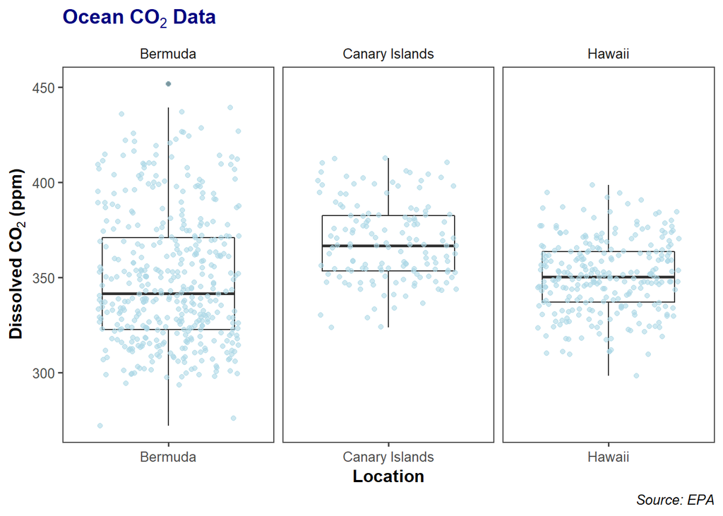

The above box plot displays the spread of the dataset separated by each location. The data from the Canary Islands and Hawaii appear to have a pretty even distribution with medians that are equally as far from the lower and upper quartiles and error bars that are very similar in length. Both of these locations also do not have any outliers. Bermuda on the other hand, has a skew towards the higher levels of carbon dioxide as the median is closer to the lower quartile and the upper error bar is much longer than the lower bar. There is also one outlier in the Bermuda data set. From this plot, it appears that the Canary Islands has the highest amounts of dissolved carbon dioxide on average, but it would not be correct to assume to conclude that the Canary Islands actually have higher levels than the other two locations because the data for the Canary Islands was not collected during the same time period as the other two, rather the data collection started later. To allow us to compare the distributions between the locations, I have now only plotted, in the plot below, the data between 2000 and 2010 as all three locations have data during this timeframe.

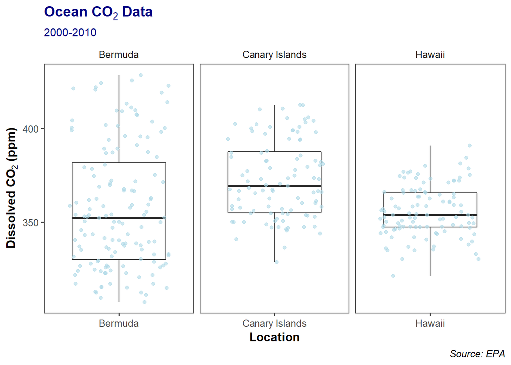

Now that the time period is controlled for between the locations, it is safe to compare their distributions. The Canary Islands still appear to have higher dissolved carbon dioxide levels on average while Bermuda and Hawaii have a very similar average. The Hawaii data is very compact and does not have much variation while Bermuda’s variation is large and still skewed a little bit upwards.

### pH

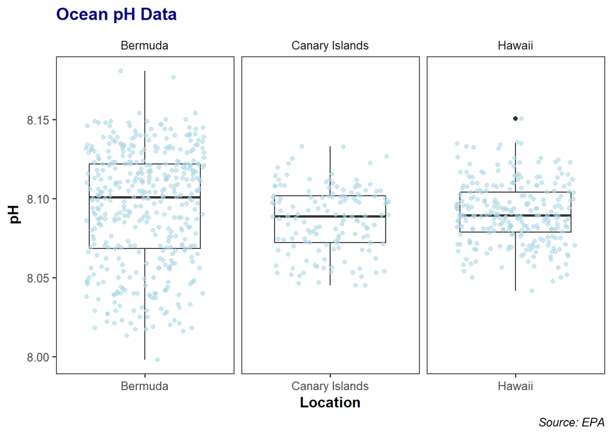

The next plot displays the distributions of the pH of the water in each region. Just as with the dissolved carbon dioxide, Bermuda has the largest variation in values of pH and is skewed a little, but this time the data has a downward skew. The medians of each location may seem to be very similar, but because this data is pH, and the pH scale is logarithmic, even the smallest nominal difference in values is a large actual difference in acidity. Both the Canary Islands and Hawaii have little variation in their values and appear to have an even distribution. Also, Hawaii has one outlier in its dataset while the other two locations do not. As with carbon dioxide levels, the timeframe of the pH data is not consistent between the regions, so in the plot below, I will just include the data from 2000-2010 again.

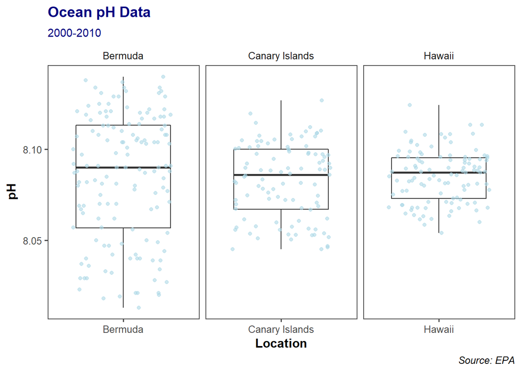

The medians of each region appear to be extremely close in value between the three regions during this timeframe, and each median for this timeframe has a lower pH value than the median pH for every year.

## Temperature Data

For data on temperature, I amassed two datasets. The first dataset was collected by NOAA and contains information on the global temperature from 1880 to 2010. This dataset does not provide the temperature during each year, but rather the temperature anomaly in °C. NOAA uses the average temperature of the entire 20th century as it’s baseline of 0 temperature anomaly.

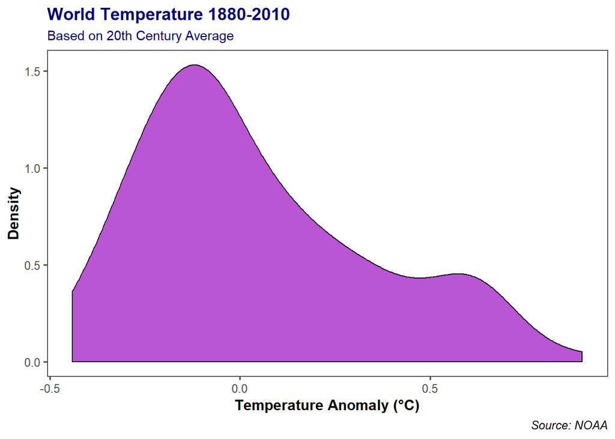

From this density curve, it is apparent that the distribution is heavily skewed right. The distribution of the data appears to be centered around a little less than 0°C. This value is reasonable because 0°C is the average temperature from the entire 20th century, which is where most of the data is measured from.

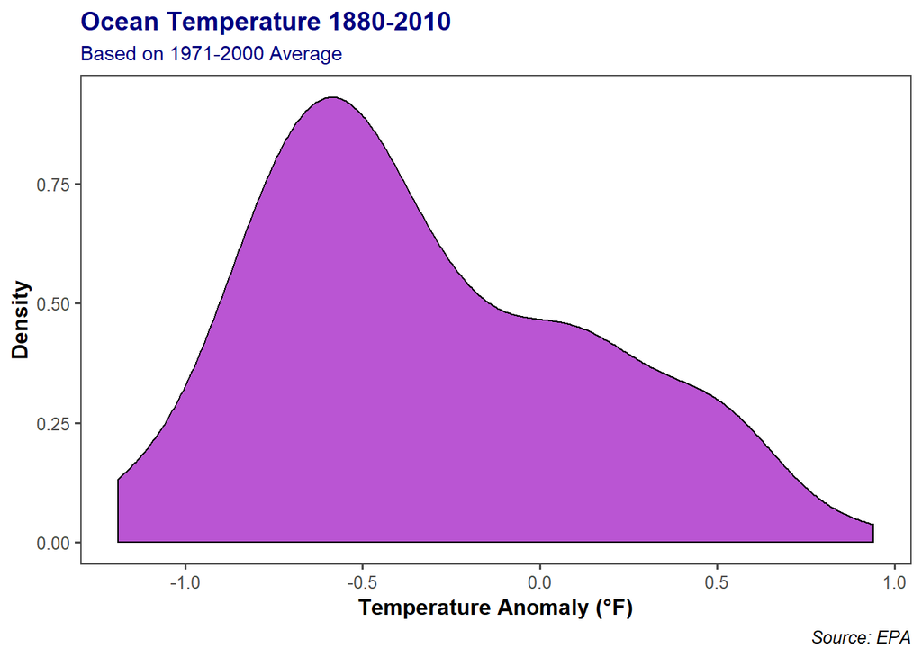

Just as with the world temperature density curve, the ocean temperature has a skewed right distribution. Contrary to the other curve, this distribution is not centered close to 0°F, rather it is closer to -0.5°F.

## Atmospheric CO<sub>2</sub>

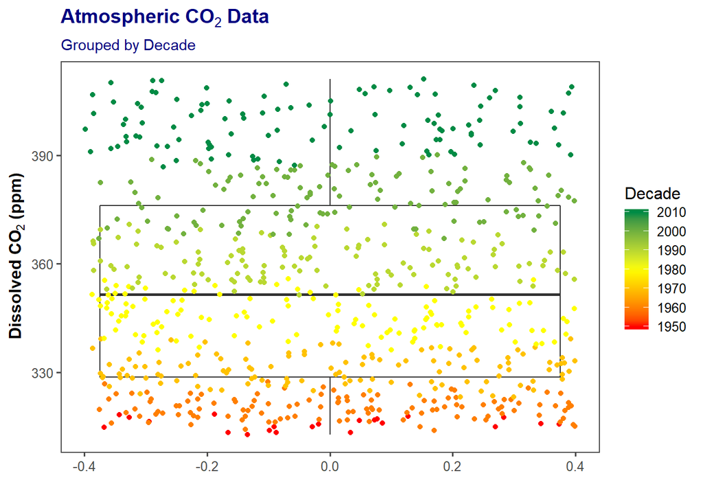

The above boxplot displays the distribution of the atmospheric CO<sub>2</sub> data. The distribution appears to be fairly even with the median being equidistant from the lower and upper quartiles. Also, by coloring the points by decade, it is clear to see a temporal trend in the data. As time goes forward, the concentration levels increase, which I will discuss more later.

# Carbon Dioxide Levels

Carbon dioxide is the fifth most abundant gas in Earth’s atmosphere. It is involved in many important aspects that allow life on Earth to be what it is now including the greenhouse effect and photosynthesis[^1]. It is a molecule that is built up of one carbon atom and two oxygen atoms and it is constantly cycled around the Earth. Because of its significance to life, it is very important to have up to date measurements of its concentrations. Measuring of CO<sub>2</sub> levels was first started by Charles David Keeling for the Scripps Institute of Oceanography. After measuring atmospheric CO<sub>2</sub> for a while, Keeling observed clear variations in the concentration levels. After discovering this, he spent the next 50 years of his life continuing to observe and understand what is occuring with atmospheric CO<sub>2</sub> and what its effects are. Because of his importance to the study of carbon dioxide, the graph below that displays the increase of atmospheric carbon dioxide is called a Keeling Curve[^2].

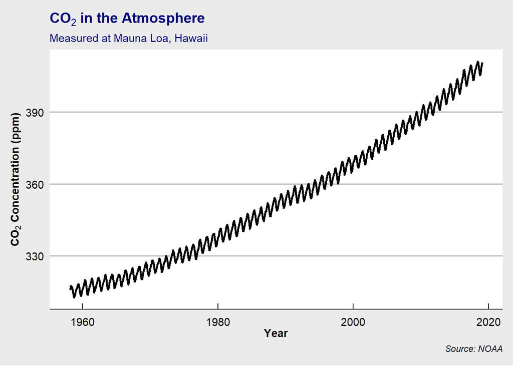

The above figure shows the concentration of atmospheric CO<sub>2</sub> throughout the second half of the 20th century and into present day. From looking at this graph, two features of carbon dioxide can be observed. Firstly, the average concentration is constantly increasing throughout the years and its rate of increase does not appear to be slowing down. The second visible feature in this graph is the seaonality shown by the repeated up and down trend in the data. I will later explore and explain the seasonality.

## Why Carbon Dioxide is Increasing

As I just illustrated, atmospheric carbon dioxide has been steadily increasing over the past century. Now, I only have data from 1958 onwards, but the concentration levels have been observed to be increasing since the start of the industrial revolution. There are many factors that have contributed to this rise. The biggest one is human burning of fossil fuels, such as coal or oil, which accounts for 75% of human emission[^3]. Fossil fuels are comprised of hydrocarbons meaning that they were formed from decayed plants and animals. Plants have been accumulating carbon dioxide through photosynthesis throughout their entire lives so when they decay or transform into a fossil fuel through extreme heat and pressure, all of that carbon is transferred. And then when the fossil fuels are burned, the carbon is released into the atmosphere. Most of the remaining 25% is caused by other activities such as deforestation and cement production[^4]. Deforestation is a double edged sword in the rise of carbon dioxide levels. Not only does removing trees from the planet stop the absorption of carbon from the atmosphere, it also causes the trees to release all of the carbon that they have been storing though photosynthesis. Due to the deforestation of over 30 million acres each year, more than 1.5 billion tons of carbon dioxide are released into the atmosphere[^5].

## Climate Change

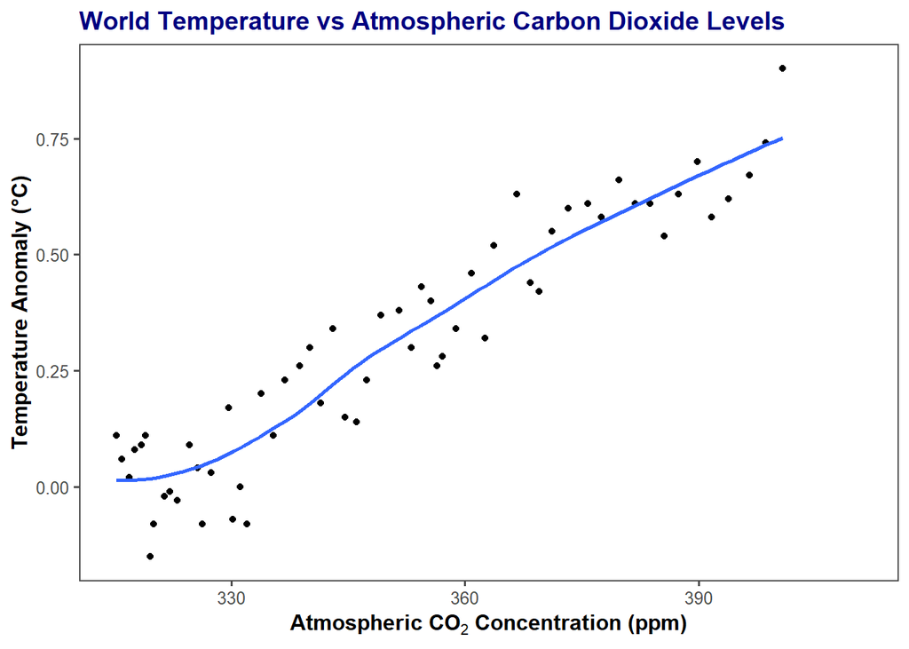

In the above figure, there appears to be a positive correlation between the concentration of atmospheric CO<sub>2</sub> and the world temperature. This result is expected as carbon dioxide is a greenhouse gas. Greenhouse gases act through the greenhouse effect which is a natural process that warms up the Earth. The light that the sun emits is not just light, it is energy in the form of waves. These waves hit the Earth’s surface and then bouce back towards space as infrared light waves that also produce heat. If there were no greenhouse gases, this radiated energy would just head right back to space, but that is not the case on Earth. If the radiated light comes in contact with a carbon dioxide particle or any other greenhouse gas particle, then the energy is rebounded into a different direction. Because there has been an increase in carbon dioxide in the atmosphere, there are more carbon dioxide particles in the air. This leads to the radiated energy from the sun to constantly bounce around in the Earth’s atmosphere and repeatedly come back into contact with the Earth’s surface which warms everything up. Without these gases, the Earth would be at least 33°C colder than it is now which is not suitable for life. In moderation, the greenhouse effect is good, but the Earth is moving towards a state where it is no longer in moderation and the Earth is getting hotter and hotter as shown in the figure below[^6].

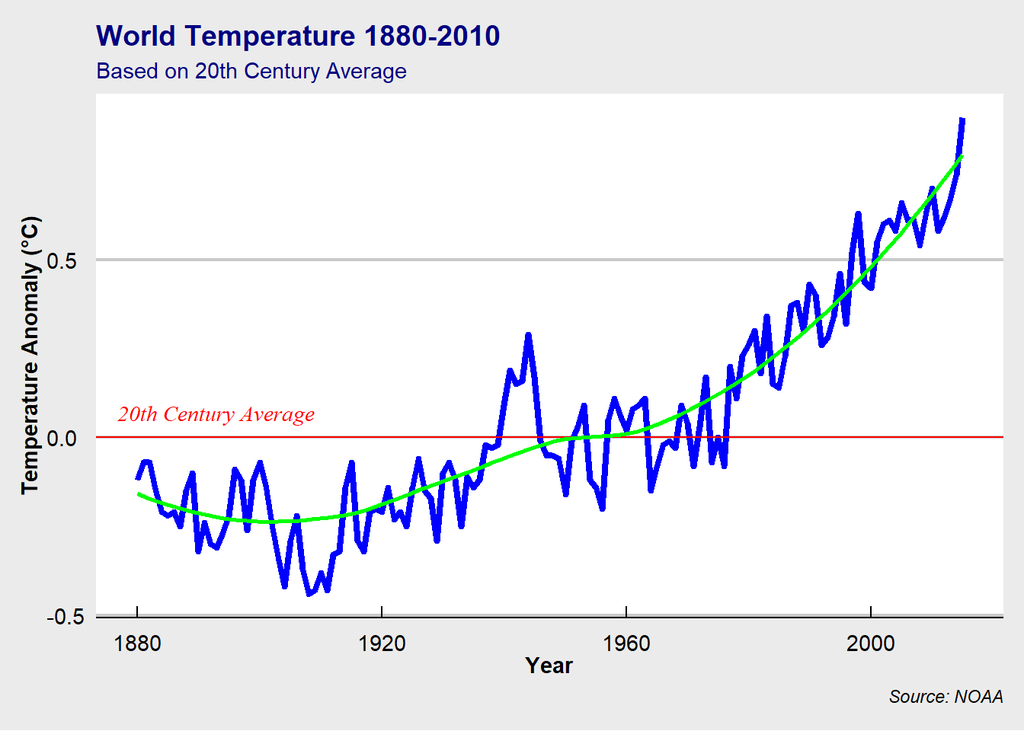

Using the 20th Century as a baseline of 0, it is clear to see that the temperature of the Earth has been increasing over the past century. Throughout the late 1800’s and the first half of the 1900’s the temperature seemed to remain pretty constant with a dip around 1900. After 1960, the slope of the regression curve, shown as a green line, started to increase and has not stopped increasing since. The rising of the average global temperature has some very negative effects to both the Earth and its inhabitants. This porject is not focused on the topic of global warming, but a few notable, detrimental effects of global warming include increased variation in precipitation, rising sea levels, increased number of hurricanes, and increased droughts and heatwaves[^7].

The graph below displays the temperature anomaly for the sea surface temperature and it looks very similar to the previous one. There is also a small dip around 1900, and then a gradual increase starting around 1960. It does seem like the temperature of the ocean may be colder as more of the data is under the baseline, but that is not the case. The baseline for the ocean temperature was calculated by the average of the timeperiod 1971-2000 which is a much smaller timeframe than the world temperature. Also because this timeframe takes place after the trend of an increasing temperature started to occur, the baseline is a higher value which makes it reasonable that much of the data is below that value.

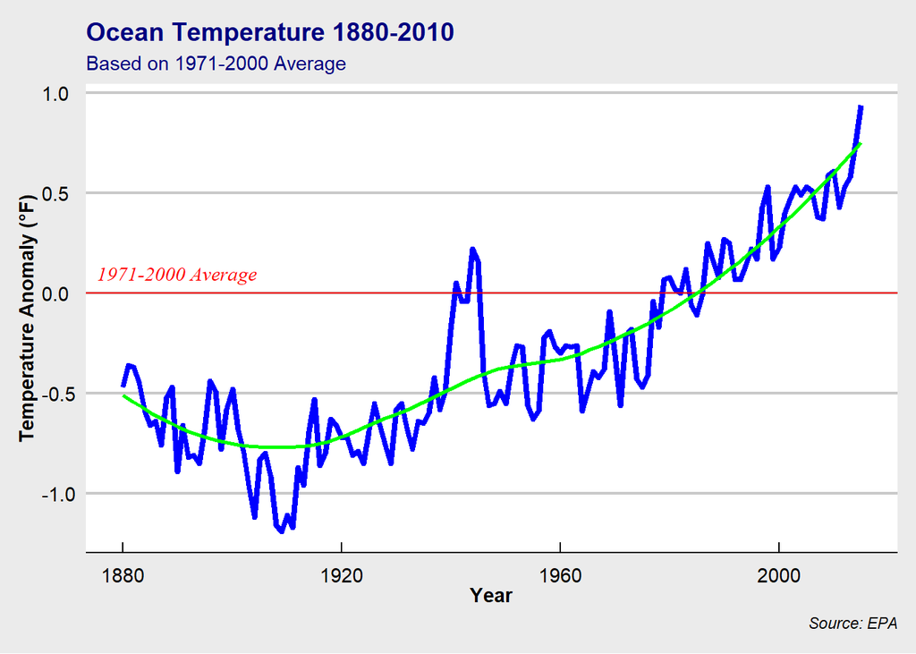

# Ocean Acidification

Ocean acidification is sometimes called the evil twin of global warming as it is also directly caused by rising carbon dioxide levels. The ocean absorbs carbon dioxide through the air sea gas exchange. This process occurs because there needs to be an equilibrium between the surface concentration levels and the atmospheric concentration levels. Some of the exchanged carbon dioxide remains in gaseous form and either freely exchanges back into the atmosphere or is directly used by phytoplankton or algae for photosynthesis, but the majority of it is dissolved into the water to create carbonic acid. This is a relatively weak acid and it is quickly disassociated into the ions of hydrogren and bicarbonate. The hydrogren ions that remain as ions reduce the pH of the seawater. The rest of the hydrogren ions bond with carbonate ions to create more bicarbonate ions and thus lessen the presence of carbonate ions. As I will discuss later, these carbonate ions are used as the building blocks for shell and skeleton creation for many marine orgnaisms[^8] [^9].

| term | estimate | std_error | statistic | p_value | lower_ci | upper_ci |
| --- | --- | --- | --- | --- | --- | --- |
| intercept | 11.58048 | 0.19402 | 59.68802 | 0 | 11.18089 | 11.98006 |
| Year | -0.00174 | 0.00010 | -17.98272 | 0 | -0.00194 | -0.00154 |

After performing a regression on the average ocean pH each year in Hawaii, I determined that the coefficient of year on pH is -.0017 and is significant at all alpha levels. This means that on average, each year, ocean pH is decreasing by .0017. This value may seem very small, but the pH scale is logarithmic, so a small change in the value of the pH has a large effect on the acidity. Between the years of 1988 and 2014, the ocean pH has dropped from 8.11 to 8.07, which once again does not seem like a big change, but is actually a 10% increase in acidity.

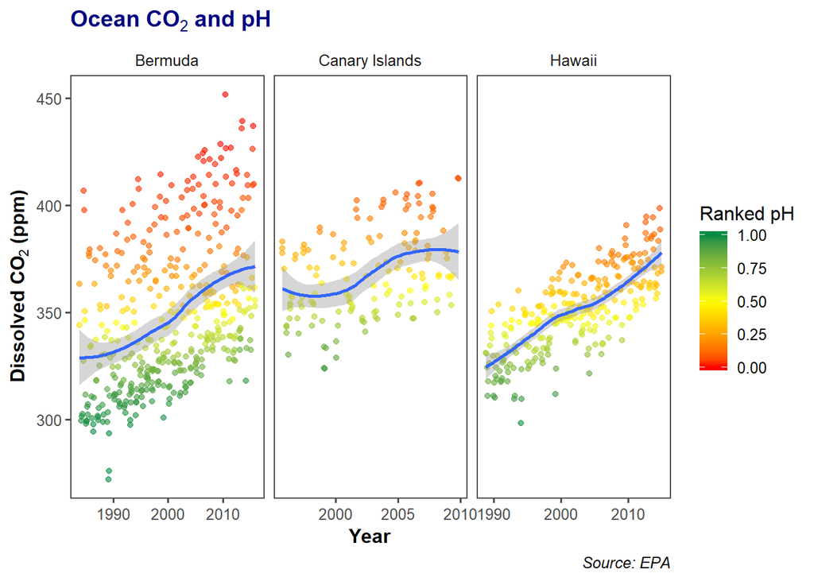

The above figure shows the carbon dioxide levels of Hawaii, Bermuda, and the Canary islands over 20-30 years. In both Hawaii and Bermuda, there is a clear positive linear trend in the data, while in the Canary Islands, the trend is still visible, though not as apparent. Each data point is also colored by its pH level. With just a glance at the graph, it is easy to see that there is a relationship between the concentration of carbon dioxide in each region’s water and its pH. As the concentration increases, the pH level decreases. As I mentioned before, carbon dioxide in the ocean is a main cause for the rising acidity levels so it makes sense that the data I amassed reveals this same relationship.

# The Relationship Between Atmospheric and Ocean CO<sub>2</sub>

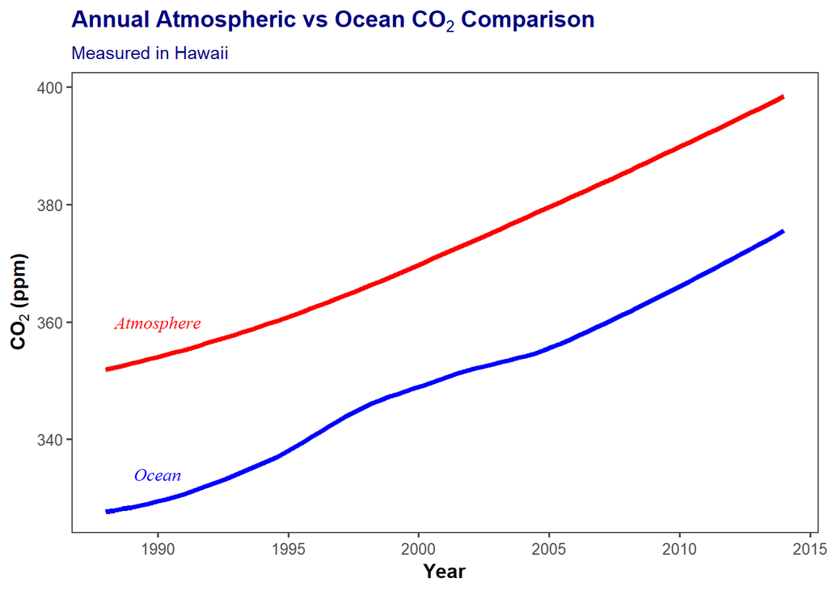

The next step I took was to examine the relationship between the CO<sub>2</sub> levels in the ocean and in the atmosphere. For the ocean, I used solely the data collected in Hawaii. The reason for this is that my atmospheric CO<sub>2</sub> data was collected above Mauna Loa which is in Hawaii, so if there is a relationship between the concentration levels, then controlling for the location site would be helpful in determining this relationship. The figure clearly shows that the atmospheric and dissolved CO<sub>2</sub> levels are increasing at the same rate. To further this evidence, the two regression tables below illustrate the slope values of each line. The first regression table is for the atmospheric CO<sub>2</sub> levels and displays a slope a 1.84. The second table is for the ocean CO<sub>2</sub> levels and displays a slope of 1.87. Both of these values are significant and are extremely close to each other. Now this could just be a correlation, but as I talked about before, the atmospheric CO<sub>2</sub> does dissolve into the oceans, so this exhibited realtionship is most likely causational.

| term | estimate | std_error | statistic | p_value | lower_ci | upper_ci |
| --- | --- | --- | --- | --- | --- | --- |
| intercept | -3301.87 | 63.36 | -52.11 | 0 | -3432.37 | -3171.37 |
| Year | 1.84 | 0.03 | 57.99 | 0 | 1.77 | 1.90 |

| term | estimate | std_error | statistic | p_value | lower_ci | upper_ci |
| --- | --- | --- | --- | --- | --- | --- |
| intercept | -3401.16 | 194.59 | -17.48 | 0 | -3801.92 | -3000.40 |
| Year | 1.87 | 0.10 | 19.28 | 0 | 1.67 | 2.07 |

## Seasonality

When discussing the atmospheric CO<sub>2</sub> levels previously, I mentioned that there was some visible seasonality in the graph. In the next two figures, I will clearly show that this seasonality is real and talk about its meaning.

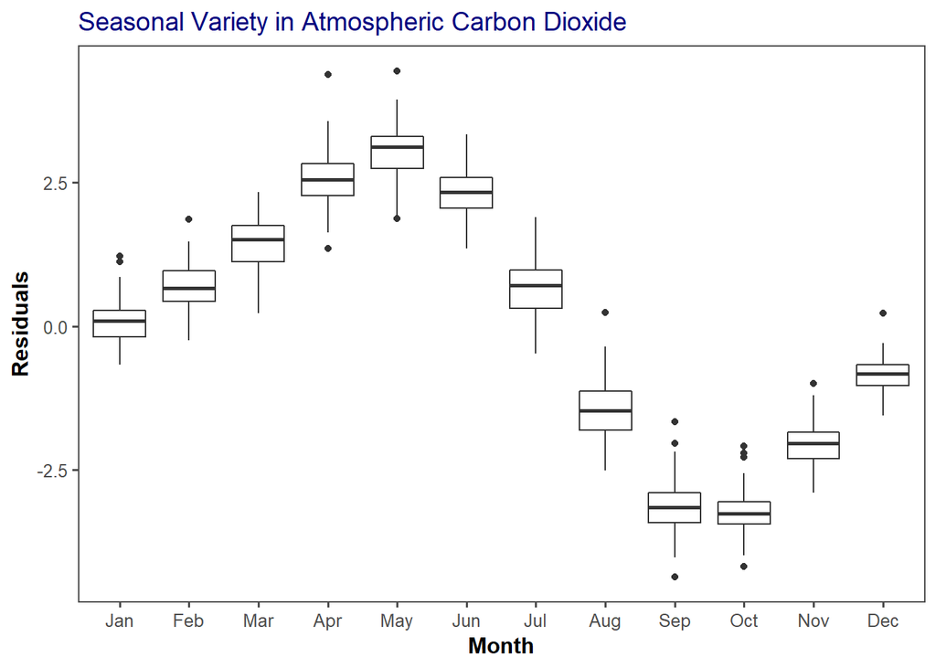

The above figure displays the residuals of the atmospheric CO<sub>2</sub> for each month. I chose to show the residuals and not just the levels of the CO<sub>2</sub> per month because this way there is no interference of a yearly trend affecting the distributions. Atmospheric CO<sub>2</sub> levels are clearly experiencing a trend involving the seasons. Spring appears to be a high point of concentration, with May containing the largest concentrations. After the spring, the levels of CO<sub>2</sub> drop lower and lower throughout the summer and then reach their lowest point in October. Then throughout the winter, the levels begin to rise again until spring. A big factor in this seasonality is plants and their life cycle. When plants are going through photosynthesis and need CO<sub>2</sub> to help produce leaves and other structural elements during the spring and summer, the levels of carbon dioxide begin to decrease and decrease as the plants are removing it from the atmosphere. On the other hand, in the fall and winter, the vegetation rots and the plants die and they release CO<sub>2</sub>[^10].

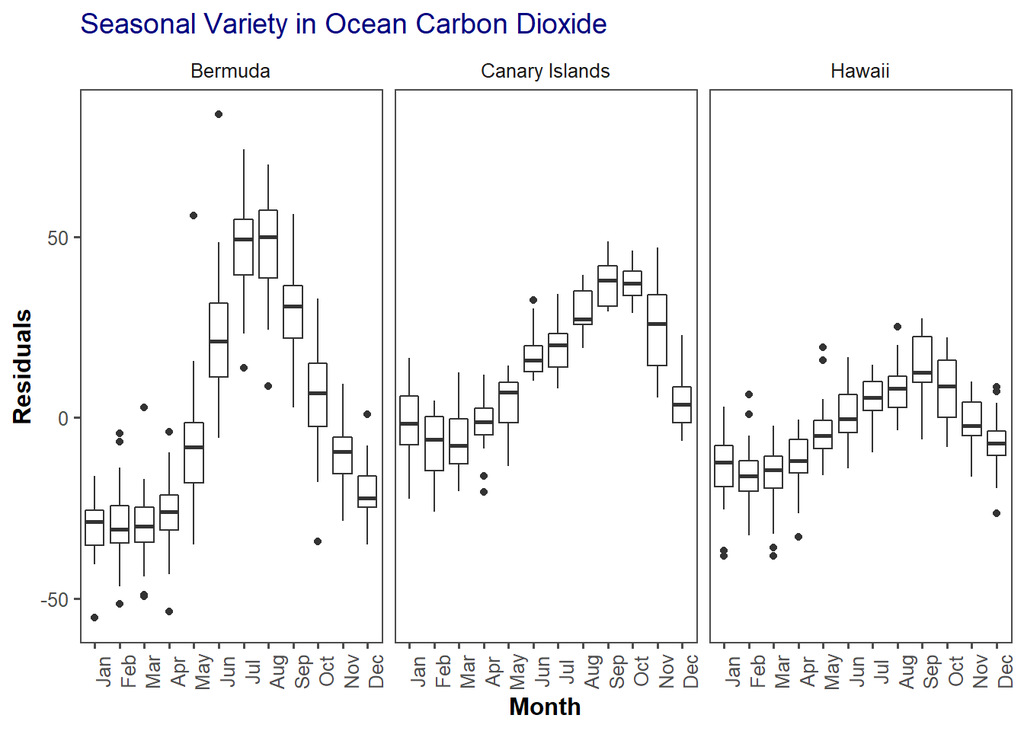

As I talked about before, the ocean absorbs CO<sub>2</sub> from the atmosphere through the air sea gas exchange. This process is not instant and takes a while to occur. From looking at the above figure which illustrates the residuals of the dissolved CO<sub>2</sub> in the ocean in each month, the seasonality is apparent. The difference between the ocean’s levels and the atmospheric levels is a few months. The atmospheric levels peaked in the spring and reached their lowest in the fall, while the ocean levels appear to peak in the summer and are their lowest in the winter, and this is most likely due to the process of dissolving CO<sub>2</sub> taking a while to occur. Another interesting thing about this figure is that Bermuda once again appears to have the most variation in its data with large residuals compared to the Canary Islands and Hawaii.

# What Does This Mean for Marine Life?

Through examining the three datasets I amassed, I have been able to determine that ocean acidification and increased levels of dissolved CO<sub>2</sub> are occuring in the world today due to the rising levels of atmospheric CO<sub>2</sub>. Both ocean acidification and increased dissolved carbon dioxide levels are big problems for marine life. The ocean already contains many so called “dead zones” in the deep sections where there is little oxygen present, and these dead zones are only going to expand due to these problems. Over the past decade, marine biologists have been studying the effects of carbon dioxide on the marine life, and they have discovered that high concentrations of CO<sub>2</sub> cause respritory problems in fish. A situation like this is very detrimental to the deep sea marine life. Not only are the oxygen levels decreasing because of the increase in dissolved CO<sub>2</sub>, but the CO<sub>2</sub> itself is hindering the fish’s ability to extract oxygen from the sea water to breathe[^11].

The changing ocean chemistry also has a negative effect on the marine life. Some ocean lifeforms such as coral and crustaceans use minerals in the ocean to create their hard shells or skeletons, especially calcium and carbonate ions to create calcium carbonate. The increase in acidity makes it more difficult for calcium carbonate to form and even leads to already made structures dissolving faster. As I discussed before, the hydrogen ions from the dissolved carbon dioxide bond with these carbonate ions, and that makes them unavailable for the calcium ions to bond to them. These organisms use these calcified structures as both protection and shelter, so when the structures are taken away from them, their lives become hard and they become more vulnerable to predators[^12].

Marine organisms also each have their own optimal conditions in which they live, and a changing environment is not good for their health. The ocean chemistry is also changing very fast as humans have caused atmospheric CO<sub>2</sub> to rapidly increase. This means that the organisms have not had sufficient time to evolve and adapt gradually, so their bodies are not prepared to undergo these environmental changes. Many of the organisms that are negatively affected by these changes are key species in the complex food webs of the ocean ecosystems. For example, there are calcifying plankton that serve as the base of their food webs and are one of the most important sources of prey to start the chain. The decrease in this plankton’s population will then have rippling effects throughout the entire food web[^13].

Ocean acidification and increased carbon dioxide levels are also affecting many marine organisms before they lives even begin. The rising acidity levels causes the sperm in some sea urchin species to move slower which lessens the chance of the sperm finding a fertilized egg and creating an embryo. So along with the sea urchins not being able to create calcified shells to protect themselves, their reproduction rate is also decreasing. This is bad news for coral reefs as sea urchins eat the algae that grows on them. There are also some fish, such as the clownfish, which have its eggs and larvae affected by the acidity changes. The increased acidity does not allow the eggs and larvae to develop properly. For example, the acidity causes the clownfish larvae to develop a very reduced sense of smell which most of the time leads to poor decision making around predators and early death[^14].

Now, even though ocean acidification has many negative effects towards much of the marine life, some organisms are appearing to thrive under the new conditions. The only downside to this is that these organisms are ones that we do not look upon in good favor, like the pests and the weeds. Two examples of this are algae and jellyfish. The algae do not directly prosper due to the increase in ocean acidity, but rather they prosper due to their predators being affected negatively by the increase. The jellyfish, on the hand, actually do perform better under these new conditions due to their body chemistry[^15].

Overall, the result of the increasing atmospheric CO<sub>2</sub> is an increased amount of dissolved CO<sub>2</sub> in the oceans which leads to a lower ocean pH or an increased level of acidity which leads to detrimental effects on the marine life. It also does not stop there. Humans will also be affected by these changes. Not only from the average global temperature increasing, but from the harm to the marine ecosystems will harm the human population. The oceans and their inhabitants serve as a large part of the human diet and sources of income. Many humans make a living from fishing, but with the fish population lessening, these people will have to have to find alternative means of income. This may mean moving away from the shores and finding new homes which is a struggle on its own. Just as these changes are happening to fast for the marine life to adapt, the same will happen to the humans and having to adapt on a large scale can only lead to more negative effects. The best way to approach this and try to prevent the humans from the need to adapt on such a scale is to reduce our carbon emissions by starting to use cleaner energy.

# References

## Data

### Ocean pH and Co2 Data

https://www.epa.gov/sites/production/files/2016-08/ocean-acidity_fig-1.csv

https://www.epa.gov/climate-indicators/climate-change-indicators-ocean-acidity

### World Temperature Data

https://www.ncdc.noaa.gov/cag/global/time-series/globe/land_ocean/ytd/12/1880-2019.csv

https://www.ncdc.noaa.gov/cag/global/time-series/globe/land_ocean/ytd/12/1880-2019

### Ocean Temperature Data

https://www.epa.gov/sites/production/files/2016-08/sea-surface-temp_fig-1.csv

https://www.epa.gov/climate-indicators/climate-change-indicators-sea-surface-temperature

## Websites

[^1]: https://sciencing.com/percentage-carbon-dioxide-up-earths-atmosphere-4474.html
[^2]: http://scrippsco2.ucsd.edu/history_legacy/early_keeling_curve
[^3]: https://www.eea.europa.eu/themes/climate/faq/are-the-increases-in-atmospheric-carbon-dioxide-and-other-greenhouse-gases-during-the-industrial-era-caused-by-human-activities
[^4]: https://www.climate.gov/news-features/understanding-climate/climate-change-atmospheric-carbon-dioxide
[^5]: https://www.climateandweather.net/global-warming/deforestation.html
[^6]: http://www.environment.gov.au/climate-change/climate-science-data/climate-science/greenhouse-effect
[^7]: https://climate.nasa.gov/effects/
[^8]: http://www.whoi.edu/OCB-OA/page.do?pid=112076
[^9]: https://www.noaa.gov/education/resource-collections/ocean-coasts-education-resources/ocean-acidification
[^10]: https://www.princeton.edu/geosciences/people/bender/CO2Sampling/varience.xml
[^11]: https://www.mbari.org/increasing-carbon-dioxide-and-decreasing-oxygen-in-the-oceans-will-make-it-harder-for-deep-sea-animals-to-breathe/
[^12]: https://www.epa.gov/ocean-acidification/effects-ocean-and-coastal-acidification-marine-life
[^13]: https://usa.oceana.org/effects-ocean-acidification-marine-species-ecosystems
[^14]: https://usa.oceana.org/effects-ocean-acidification-marine-species-ecosystems
[^15]: https://usa.oceana.org/effects-ocean-acidification-marine-species-ecosystems